# For Live Session Unit 1 CLT

Isabella Westlauer

1/21/2026

# Simulator to Demonstrate CLT

## 1. Generate a Population using rchisq()

Adapt the code to generate a population of 10,000,000 from a chi-square  
distribution with 2 degrees of freedom. This is a heavily right  
skewed distribution. (Hint: rchisq()). You will have to read up on this  
function and probably do some trial and error. Being able to learn new  
functions and methods is a key skill.

```r
n = 1.0e7 # number of data points = 10,000,000
df = 2 # degrees of freedom, or number of independent variables
ncp = 0 # non-centrality parameter
# rchisq(n, df, ncp) generates random numbers from a chi-square distribution
population = rchisq(n=n,df=df, ncp=ncp)
```

## 2. Histogram of the Population

Provide a histogram of this population… display the right skewness.

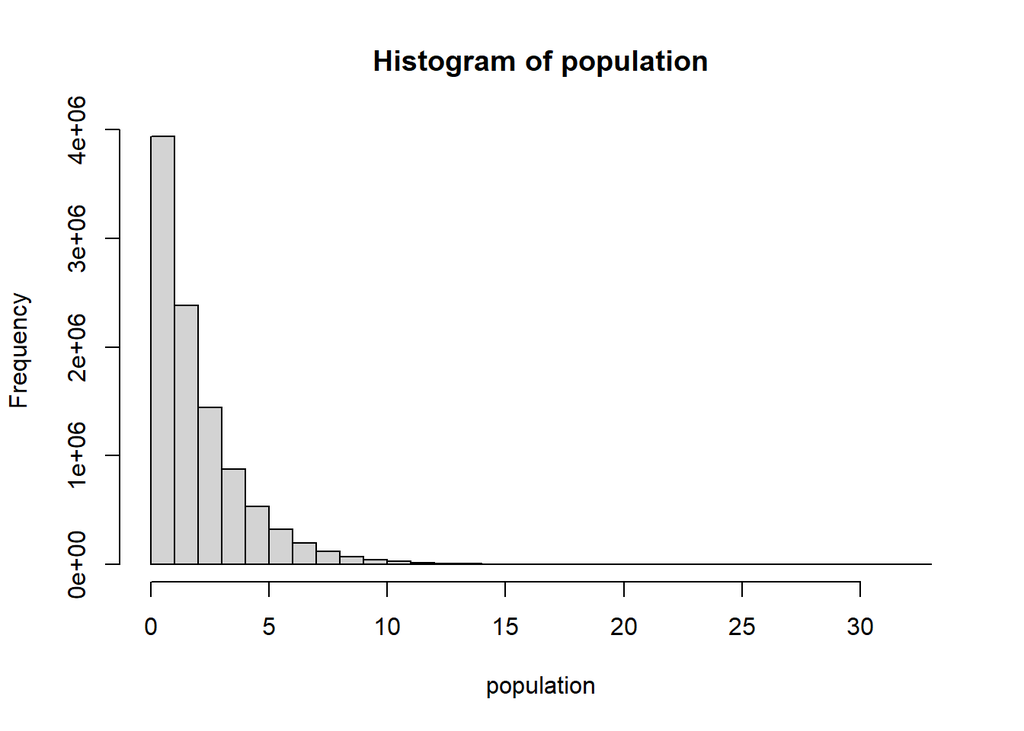

```r
hist(population)
```

## 3. Record the mean and standard deviation of this population.

```r
mu = mean(population) # about 2.0
mu
```

```
## [1] 2.000509
```

```r
sigma = sd(population) # about 2.0
sigma
```

```
## [1] 2.000175
```

## 4. Expected Distribution vs. Simulated Distribution

According to the central limit theorem, what should be the approximate distribution of sample means of size 50 from this right skewed population?  
What should be the mean and standard error of the mean (standard deviation of the distribution of sample means)?

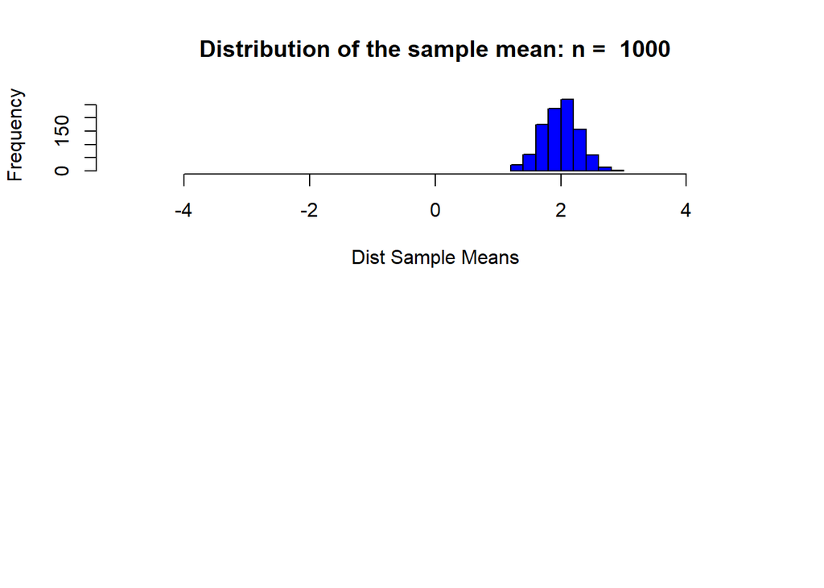

```r
sample_size = 50
num_samples1 = 1.0e3 # number of samples and thus number of xbars
xbar_holder1 = numeric(num_samples1) # This will hold all the sample means for dist 1
for (i in 1:num_samples1)
{
  sample1 = rnorm(sample_size,mean = mu, sd = sigma)
  xbar1 = mean(sample1)
  xbar_holder1[i] = xbar1
}

par(mfrow = c(2,1))
# The approximate distribution of the sample mean: num_samples = 1,000
hist(xbar_holder1, col = "blue", main = paste("Distribution of the sample mean: n = ", num_samples1), xlab = "Dist Sample Means", xlim = c(-5,5))
```

```r
# the standard error of the mean is sigma/sqrt(length(population))
se = sigma / sqrt(n)

summary(xbar_holder1) #5 number summary and the mean
```

```
##    Min. 1st Qu.  Median    Mean 3rd Qu.    Max.
##   1.218   1.789   2.005   1.991   2.189   2.917
```

```r
sd(xbar_holder1) # standard deviation of distribution
```

```
## [1] 0.2837554
```

## 5. Increase Number of Samples, keeping sample size at 50

Now let’s check this: Adapt the CLT code to draw 10,000 means each of size 50 from this population and provide the sampling distribution of this sample mean. Provide a histogram of these 10,000 sample means.

```r
num_samples2 = 1.0e4 # try a larger number of samples
xbar_holder2 = numeric(num_samples2) # This will hold all the sample means for dist 2
for (i in 1:num_samples2)
{
  sample2 = rnorm(sample_size,mean = mu, sd = sigma)
  xbar2 = mean(sample2)
  xbar_holder2[i] = xbar2
}
```

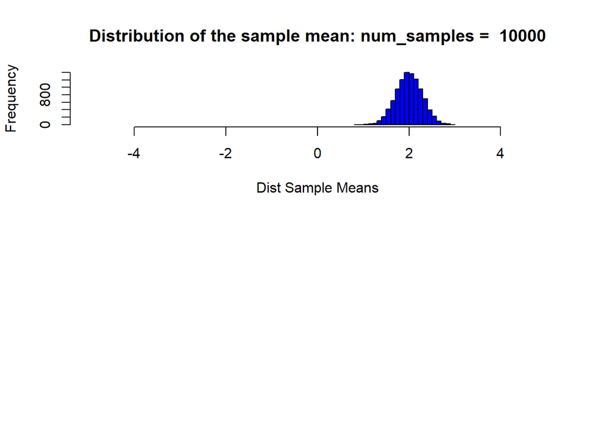

```r
par(mfrow = c(2,1))
# The approximate distribution of the sample mean: num_samples = 10,000
hist(xbar_holder2, col = "blue", main = paste("Distribution of the sample mean: num_samples = ", num_samples2), xlab = "Dist Sample Means", xlim = c(-5,5))
```

## 6. Mean and Standard Deviation, 1,000 vs 10,000 samples

What is the mean and standard deviation of these 10,000 sample means?

```r
summary(xbar_holder2) #5 number summary and the mean
```

```
##    Min. 1st Qu.  Median    Mean 3rd Qu.    Max.
##   0.881   1.809   2.000   2.000   2.193   2.975
```

```r
sd(xbar_holder2) # standard deviation of distribution
```

```
## [1] 0.2826459
```